# Python数据处理

## 02. Python基本语法

主讲人：丁平尖

## Python基本语法

**函数 条件 递归 迭代 字符串 列表 字典 元组**

**文件 类和对象 类和函数 类和方法 继承**

## 函数

- 我们已经见过一些函数的例子：例如：type()和print()
- 函数的调用形式：函数名(函数参数)
- 一个函数可以输入零个或多个参数，也可以返回零个或多个值

```python
import math
rt2 = math.sqrt(2)
print(rt2)
```

```
1.4142135623730951
```

- Python的‘math’模块提供了许多数学函数。我们在使用这些函数之前，**必须先导入该模块**。然后使用’math.sqrt()’来调用’math’模块中的‘sqrt’函数。
- ‘math.sqrt()’接收一个参数，返回其平方根

## 函数

```python
a = 2
b = 3
math.pow(a, b)
```

```
8.0
```

- ‘math.pow()’接受两个参数，返回第一个参数的第二个参数次幂

Python math模块的文档：https://docs.python.org/zh-cn/3/library/math.html

## 定义函数

- 我们可以使用函数定义来创建新函数，这样我们就可以在需要时调用它。

```python
# ‘def’关键字告诉Python，我们正在定义一个函数。
def return_multiple_values(text):
    '''
    函数的任何参数都在括号内给出。
    冒号（:）用于表示缩进代码块的开始。
    '''
    value1 = 10 # 空白符可以是制表符或空格，只要保持一致即可。
    value2 = text
    value3 = [1, 2, 3]
    return value1, value2, value3 # 使用‘return’关键字，定义函数的返回结果。

# 下一行不属于函数主体，通过缩进向Python传达这一事实。
result1, result2, result3 = return_multiple_values("hello")
print(result1)
print(result2)
print(result3)
```

```
10
hello
[1, 2, 3]
```

注意：在R、C/C++和Java等语言中，代码块用大括号（{}）组织的。Python是以空白符号分隔的。

## 布尔表达式

- 布尔表达式用于判断语句的真伪。
- ‘bool’类型的变量可以是“True”或“False”。
- Python中提供了一些比较运算符。
  - 涉及比较运算符的表达式会返回一个布尔值。

```python
x, y = 20, 10
x == y # x is equal to y
x != y # x is not equal to y
x > y # x is strictly greater than y
x < y # x is strictly less than y
x >= y # x is greater than or equal to y
x <= y # x is less than or equal to y
```

## 布尔表达式

- 通过逻辑运算符‘and’、‘or’和‘not’将布尔表达式组合成更大的表达式。

```python
x = 10
x < 20 and x > 0
```

```
True
```

```python
x > 100 and x > 0
```

```
False
```

```python
x > 100 or x > 0
```

```
True
```

```python
not x > 0
```

```
False
```

## 条件执行

- 有时我们希望根据某些条件执行不同的操作，最简单的就是‘if’语句了。

```python
def pos_neg_or_zero(x):
    if x < 0: # 这个布尔表达式成为测试条件，或者简称为条件。
        # 如果条件评估为“True”（真），那么Python将运行‘if’语句主体中的代码。
        # 如果条件评估为‘False’（假），那么Python将跳过主体，并从‘if’语句末尾继续运行代码。
        print('That is negative')
    elif x == 0: # elif是‘else if’ 的缩写
        print('That is zero.')
    else: # 如果所有其他条件都不成立，我们将执行‘else’部分的代码块。
        print('That is positive')

pos_neg_or_zero(1)
```

```
That is positive
```

```python
pos_neg_or_zero(0)
pos_neg_or_zero(-100)
pos_neg_or_zero(20)
```

```
That is zero.
That is negative
That is positive
```

## 条件执行

注意：条件语句的主体可以包含任意数量的代码行，但必须至少有一行。如果不想执行任何操作，可以使用‘pass’关键字。

```python
def thres_100(y):
    if y > 100:
        pass
    if y < 100:
        print('y is less than 100')

thres_100(200)
thres_100(0)
```

```
y is less than 100
```

## 递归

- 一个函数被允许调用它自己，这就是所谓的递归

```python
def countdown(n):
    if n <= 0:
        print('We have lift off!')
    else:
        print(n)
        countdown(n-1)
countdown(3)
```

```
3
2
1
We have lift off!
```

## 递归

- 稍作修改，函数将会无限递归

```python
def countdown(n):
    if n <= 0:
        print('We have lift off!')
    else:
        print(n)
        countdown(n)
countdown(3)
```

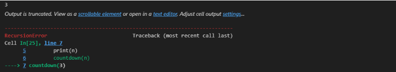

## 迭代

- 递归是我们看到的第一个用于执行重复操作的工具。
- 但是有更好的工具来完成这项工作:**while循环**和**for循环**

```python
a = 4
x = 3.5
epsilon = 10**-6
while True:
    print(x)
    y = (x + a/x)/2
    if abs(x-y) < epsilon:
        break # break关键字在被调用时终止当前循环。
    x=y # update to our new estimate
```

```
3.5
2.321428571428571
2.022252747252747
2.000122433944265
2.0000000037472883
```

## 字符串

- 字符串是字符序列

```python
animal = 'goat'
letter = animal[1]
letter
# Python序列从0开始计数
```

```
'o'
```

```python
'''
注意：在某些语言中，字符和长度为1的字符串是有区别的。
也就是说，字符‘g’和字符串“g”是不同的数据类型。
在Python中，不存在这样的区别。一个字符就是一个单字符字符串。
'''
animal[1]
```

```
'o'
```

```python
animal[2]
```

```
'a'
```

## 字符串（迭代和遍历：for循环）

```python
i = 0
while i < len(animal):
    print(animal[i])
    i = i + 1
```

```
g
o
a
t
```

```python
for c in animal:
    print(c)
# For循环提供了一种简洁的方式来表达。
```

```
g
o
a
t
```

## 字符串切片

- Python序列的一段成为切片。

```python
s = "And now for something completely different"
# String[:m]选取从0开始到第(m-1)个字符的子序列。
s[:7]
```

```
'And now'
```

```python
# String[m :]选取从第m个字符开始到序列末尾的子序列。
s[22:]
```

```
'completely different'
```

- 切片也适用于负数索引。

```python
s[-20: -10]
```

```
'completely'
```

```python
s[-20:]
```

```
'completely different'
```